# Assignment1

### e. Find and interpret the mean, median, and mode for each of the voltage readings data sets. Which is the preferred measure of central tendency? Explain.

```r
#OLD
#The mean
mean(old$VOLTAGE)
```

```
## [1] 9.803667
```

```r
#The median
median(old$VOLTAGE)
```

```
## [1] 9.975
```

```r
#The mode https://www.r-bloggers.com/computing-the-mode-in-r/
getmode = function(x){
    ta = table(x)
    tam = max(ta)
    if (all(ta == tam))
         mod = NA
    else
         if(is.numeric(x))
    mod = as.numeric(names(ta)[ta == tam])
    else
         mod = names(ta)[ta == tam]
    return(mod)
}
getmode(old$VOLTAGE)
```

```
## [1]  8.72  9.80  9.84  9.87  9.98 10.05 10.15 10.26
```

```r
#NEW
#The mean
mean(new$VOLTAGE)
```

```
## [1] 9.422333
```

```r
#The median
median(new$VOLTAGE)
```

```
## [1] 9.455
```

```r
#The mode
getmode(new$VOLTAGE)
```

```
## [1] 8.82
```

> The median would be prefered over the mean since the data is very skewed toward the upper classes. The mode tell us very little in this data as almost of them are unique

### f. Calculate the z-score for a voltage reading of 10.50 at the old location.

```r
# z-score = (x-μ)/σ
z = (10.5 - mean(old$VOLTAGE))/sd((old$VOLTAGE))
z
```

```
## [1] 1.287324
```

### g. Calculate the z-score for a voltage reading of 10.50 at the new location.

```r
z = (10.5 - mean(new$VOLTAGE))/sd((new$VOLTAGE))
z
```

```
## [1] 2.25041
```

### h. Based on the results of parts f and g, at which location is a voltage reading of 10.50 more likely to occur? Explain.

> More likely occur in OLD

### i. Construct a box plot for the data at the old location. Do you detect any outliers?

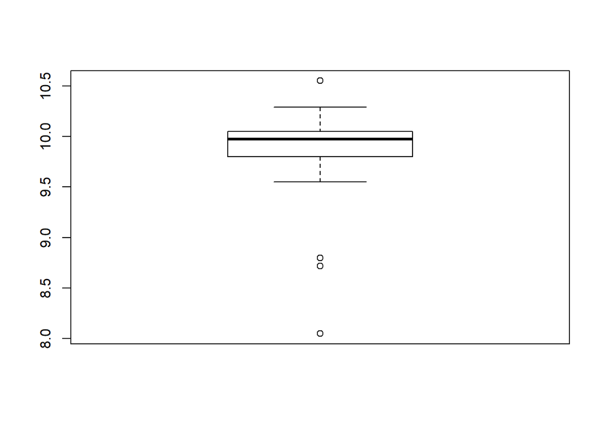

```r
boxplot(old$VOLTAGE)
```

> Yes, there is 4 of them

### j. Use the method of z-scores to detect outliers at the old location.

```r
library (lattice)
old.z=(old$VOLTAGE-mean(old$VOLTAGE))/sd(old$VOLTAGE)
# The likely outliners
old.z[abs(old.z)>=2 & abs(old.z)<=3]
```

```
## [1] -2.003394 -2.003394
```

```r
# The outliners
old.z[abs(old.z)>3]
```

```
## [1] -3.242035
```

### k. Construct a box plot for the data at the new location.Do you detect any outliers?

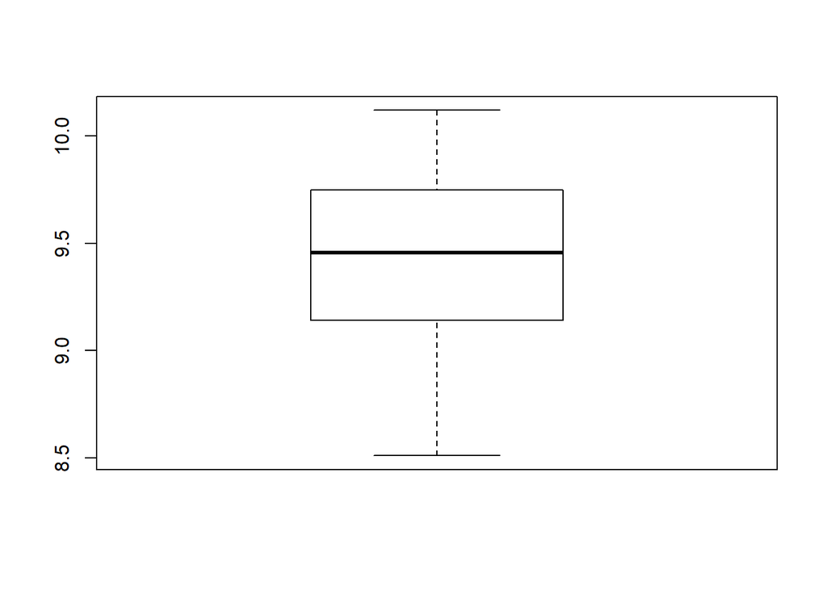

```r
boxplot(new$VOLTAGE)
```

> No

### l. Use the method of z-scores to detect outliers at the new location.

```r
new.z=(new$VOLTAGE-mean(new$VOLTAGE))/sd(new$VOLTAGE)
# The likely outliners
new.z[abs(new.z)>=2 & abs(new.z)<=3]
```

```
## numeric(0)
```

```r
# The outliners
new.z[abs(new.z)>3]
```

```
## numeric(0)
```

### m. Compare the distributions of voltage readings at the two locations by placing the box plots, parts i and k, side by side vertically.

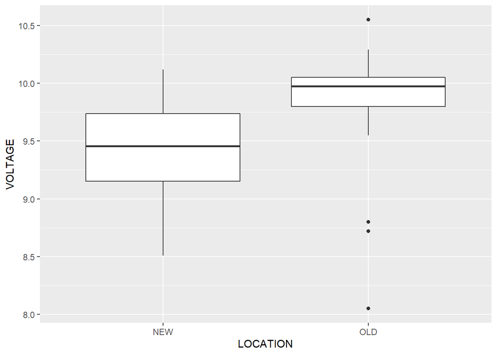

```r
library(ggplot2)
g = ggplot(voltage, aes(x=LOCATION, y=VOLTAGE)) + geom_boxplot()
g
```

## 12. MS 2.73 - pg 70 Give an interval that will likely contain about 95% of all coated pipe roughness measurements.

```r
# https://www.cyclismo.org/tutorial/R/confidence.html
rp = read.csv("ROUGHPIPE.csv")
m = mean(rp$ROUGH)
sd = sd(rp$ROUGH)
error = qnorm(0.975)*sd/sqrt(nrow(rp))
left = m-error
right = m+error

# 95% measurements can be found
# From
print(left)
```

```
## [1] 1.65139
```

```r
# To
print(right)
```

```
## [1] 2.11061
```

## 13. MS 2.80 - pg 72

```r
ga = read.csv("GOBIANTS.csv")
```

### a. Find the mean, median, and mode for the number of ant species discovered at the 11 sites. Interpret each of these values.

```r
#The mean
with(ga,mean(AntSpecies))
```

```
## [1] 12.81818
```

```r
#The median
with(ga,median(AntSpecies))
```

```
## [1] 5
```

```r
#The mode
with(ga,getmode(AntSpecies))
```

```
## [1] 4 5
```

### c. Find the mean, median, and mode for the total plant cover percentage at the 5 Dry Steppe sites only.

```r
ga.dry=subset(ga, Region=="Dry Steppe ")
#The mean
with(ga.dry,mean(PlantCov))
```

```
## [1] 40.4
```

```r
#The median
with(ga.dry,median(PlantCov))
```

```
## [1] 40
```

```r
#The mode
with(ga.dry,getmode(PlantCov))
```

```
## [1] 40
```

### d. Find the mean, median, and mode for the total plant cover percentage at the 6 Gobi Desert sites only.

```r
ga.gobi=subset(ga, Region=="Gobi Desert")
#The mean
with(ga.gobi,mean(PlantCov))
```

```
## [1] 28
```

```r
#The median
with(ga.gobi,median(PlantCov))
```

```
## [1] 26
```

```r
#The mode
with(ga.gobi,getmode(PlantCov))
```

```
## [1] 30
```

### e. Based on the results, parts c and d, does the center of the total plant cover percentage distribution appear to be different at the two regions?

> Yes, there are more plants in Dry Steppe

## 14. MS 2.84 - pg 74

```r
library("readxl")
gal=read_excel("GALAXY2.xls")
```

1. Use a graphical method to describe the velocity distribution of galaxy cluster A1775.

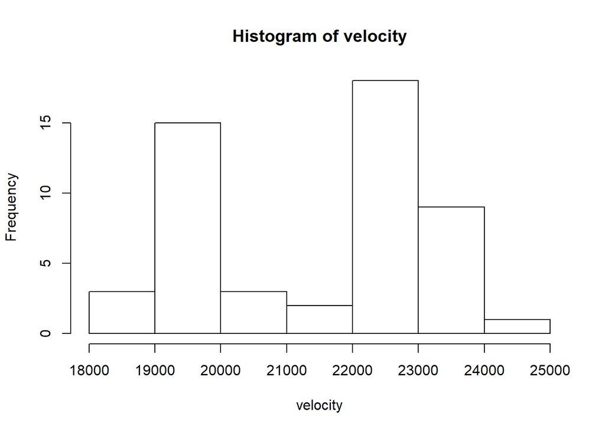

```r
velocity = gal$VELOCITY
hist(velocity)
```

2. Examine the graph, part a. Is there evidence to support the double cluster theory? Explain. > It looks like there are two interval, centered aroud 18000-21000 and 21000-25000. This is the eviden that support the double cluster theory
3. Calculate numerical descriptive measures (e.g., mean and standard deviation) for galaxy velocities in cluster A1775. Depending on your answer to part b, you may need to calculate two sets of numerical descriptive measures, one for each of the clusters (say, A1775A and A1775B) within the double cluster.

```r
#Cluster A VELOCITY<21000
clusterA = subset(gal, VELOCITY<21000)
#The Mean
with(clusterA,mean(VELOCITY))
```

```
## [1] 19462.24
```

```r
#The median
with(clusterA,median(VELOCITY))
```

```
## [1] 19408
```

```r
#The mode
with(clusterA,getmode(VELOCITY))
```

```
## [1] NA
```

```r
#The Standard Deviation
with(clusterA,sd(VELOCITY))
```

```
## [1] 532.2868
```

```r
#Cluster B VELOCITY>21000
clusterB = subset(gal, VELOCITY>21000)
#The Mean
with(clusterB,mean(VELOCITY))
```

```
## [1] 22838.47
```

```r
#The median
with(clusterB,median(VELOCITY))
```

```
## [1] 22780
```

```r
#The mode
with(clusterB,getmode(VELOCITY))
```

```
## [1] NA
```

```r
#The Standard Deviation
with(clusterB,sd(VELOCITY))
```

```
## [1] 560.9767
```

4. Suppose you observe a galaxy velocity of 20,000 km/s. Is this galaxy likely to belong to cluster A1775A or A1775B? Explain. > It would be likely belong the cluster A since at 20000 is where the the highest frequency of cluster A

## 15. Using the ddt data set re-create the plot below using ggplot

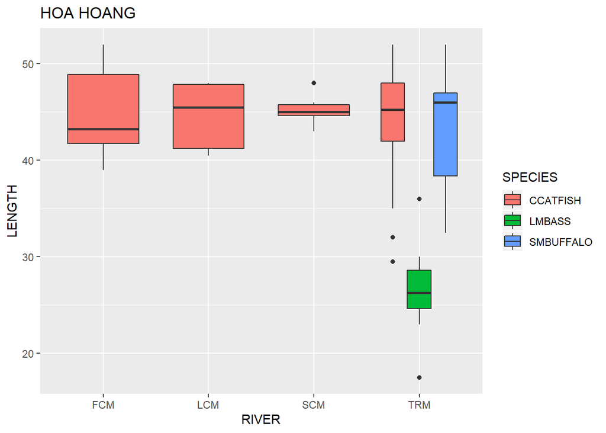

```r
library(ggplot2)
ddt = read.csv("DDT.csv")
g = ggplot(ddt,aes(x=RIVER, y=LENGTH, fill=SPECIES,)) + geom_boxplot() +ggtitle("HOA HOANG")
g
```